# Meqsure of Skewness and Measures of Location

by Craig Slinkman

9/2/2020

This document will demonstrate the effects of skewness on the mean median and mode. Examples of symmetric, negatively skewed data, and positively skewed data.

The R-code for this example will be embedded in this document. For the answer to the Quora question will be copied and pasted into the Quora for the answers.

## Preperation of R

We need to set up R so that we can perform our analysis. We do this in the code chunk below. This code will be executed and included in the output when the document is rendered by knitter.

```r
require( knitr)       # To set global directory
require(tidyverse)
require(Lock5withR)    # For body temperature data ...
require( DescTools )   # To compute the mode ...
```

```r
require( cowplot )     # For professional publication graphics ...
wd <- file.path("D:/",
                "R-Projects",
                "Quora",
                "Skewness" )

knitr::opts_knit$set(root.dir = wd )
getwd()
```

```
## [1] "D:/R-Projects/Quora/Skewness"
```

## The data sets we will use

There are three data sets that we will use in this analysis.

The first data set body temperature (in Fahrenheit) and pulse rates set used in the statistics text [Statistics: Unlocking the power of data](https://www.wiley.com/en-us/Statistics%3A+Unlocking+the+Power+of+Data%2C+2nd+Edition-p-9781119308843). I liked this book because it explained sampling distributions and the use of the bootstrap. There is an R-package called **Lock5withR** that has the bootstrap.

We access the data in the following chunk:

```r
###############################################################################
# I prefer to work with tibbles so I an going to cast the data.frame
# BodyTemp50 to a tibble.  We then display the tibble so we all have an idea
# of the nature of the data.
###############################################################################

BodyTemp50 <- as_tibble( BodyTemp50 )
BodyTemp50
```

```
## # A tibble: 50 x 4
##    BodyTemp Pulse Gender Sex
##       <dbl> <int>  <int> <fct>
##  1     97.6    69      0 Female
##  2     99.4    77      1 Male
##  3     99      75      0 Female
##  4     98.8    84      1 Male
##  5     98      71      0 Female
##  6     98.9    76      1 Male
##  7     99      81      0 Female
##  8     97.8    77      1 Male
##  9     96.8    75      1 Male
## 10     99      81      1 Male
## # ... with 40 more rows
```

This data consists of 50 body temperatures and pulse rates for a sample of 50 observations. It also includes the gender of the adult. the orginal data source is: Shoemaker, “What is Normal Temperature, Gender and Heart Rate”, Journal of Statistics Education,Vol. 4, No. 2 (1996)e of 50 adults.

### Draw histogram and density diagram

```r
###############################################################################
# Compute mean, median, and mode, see we can plot their position on the
# histogram we will draw.
###############################################################################

mean_bt   <- round( mean( BodyTemp50$BodyTemp ),1 )
median_bt <- round( median( BodyTemp50$BodyTemp ),1)
mode_bt   <- Mode(  BodyTemp50$BodyTemp, na.rm = TRUE )

mean_bt
```

```
## [1] 98.3
```

```r
median_bt
```

```
## [1] 98.2
```

```r
mode_bt
```

```
## [1] 98.2
## attr(,"freq")
## [1] 5
```

```r
limits <- pretty( BodyTemp50$BodyTemp,
                  n = 5,
                  high.u.bias = 10 )
```

### Drawing the histogram with ggplot2

We draw the plot using the R-code below:

```r
scale_y <- seq( from = 0,
                to   = 30,
                by   = 5 )

 mean_bt
```

```
## [1] 98.3
```

```r
 median_bt
```

```
## [1] 98.2
```

```r
 mode_bt
```

```
## [1] 98.2
## attr(,"freq")
## [1] 5
```

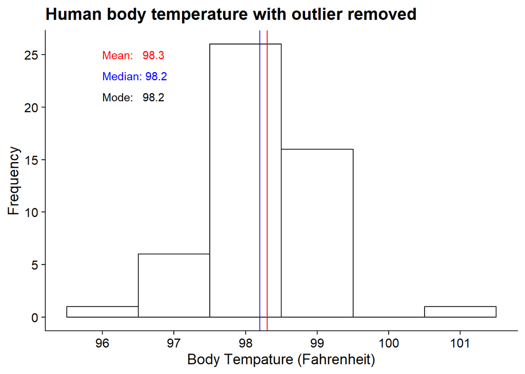

```r
temp50 <-
    ggplot( BodyTemp50, aes( x = BodyTemp )) +
        geom_histogram( binwidth = limits[2] - limits[1],
                      color = "black",
                       fill = "white" ) +
        geom_vline( xintercept = mean_bt,   color = "red") +
        geom_vline( xintercept = median_bt, color="blue")  +
        annotate( "text",
                   x = 96, y = 25,
                   label = "Mean:   98.3",
                   hjust = 0,
                   color = "red") +
         annotate( "text",
                    x = 96, y = 23,
                    label = "Median: 98.2",
                    hjust = 0,
                    color = "blue") +
         annotate( "text",
                     x = 96, y = 21,
                     label = "Mode:   98.2",
                     hjust = 0,
                     color = "black" ) +
         scale_x_continuous( name = "Body Tempature (Fahrenheit)",
                             breaks = limits,
                             label  = limits ) +
         scale_y_continuous( name = "Frequency",
                             breaks = scale_y,
                             labels = scale_y ) +
         ylab( "Frequency" ) +
         ggtitle( "Human body temperature with outlier removed" ) +
         theme_cowplot()

fp <- file.path( wd,
                 "plots",
                 "BodyTemp50.jpeg")

save_plot( fp, temp50 )

temp50
```

This is an example of an approximately symmetric distribution with an outlier. Note that the outlier is probably an ill student. Note that that this observation move the mean to the right of the median. We probably should remove this outlier.

```r
BodyTemp49 =
    BodyTemp50 %>%
        filter( BodyTemp < 100 )

mean_bt   <- round( mean( BodyTemp49$BodyTemp ),1 )
median_bt <- round( median( BodyTemp49$BodyTemp ),1)
mode_bt   <- Mode(  BodyTemp49$BodyTemp, na.rm = TRUE )


 mean_bt
```

```
## [1] 98.2
```

```r
 median_bt
```

```
## [1] 98.2
```

```r
 mode_bt
```

```
## [1] 98.2
## attr(,"freq")
## [1] 5
```

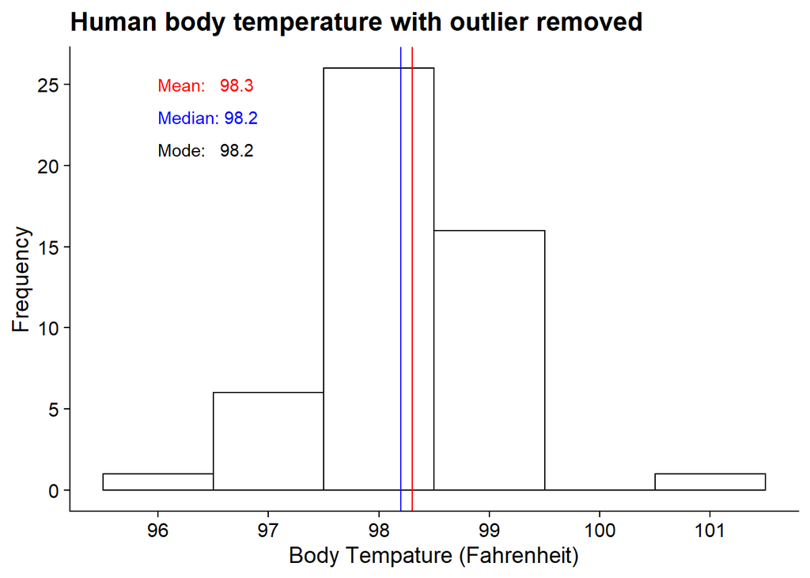

```r
temp49 <-
    ggplot( BodyTemp49, aes( x = BodyTemp )) +
        geom_histogram( binwidth = limits[2] - limits[1],
                        color = "black",
                        fill = "white" ) +
        geom_vline( xintercept = mean_bt,   color = "red") +
        geom_vline( xintercept = median_bt, color="blue")  +
        annotate( "text",
                  x = 96, y = 25,
                  label = "Mean:   98.2",
                  hjust = 0,
                  color = "red") +
         annotate( "text",
                    x = 96, y = 23,
                    label = "Median: 98.2",
                    hjust = 0,
                    color = "blue") +
         annotate( "text",
                    x = 96, y = 21,
                    label = "Mode:  98.2",
                    hjust = 0,
                    color = "black" ) +
         scale_x_continuous( name = "Body Tempature (Fahrenheit)",
                             breaks = limits,
                             label  = limits ) +
         scale_y_continuous( name = "Frequency",
                             breaks = scale_y,
                             labels = scale_y ) +
         ggtitle( "Human body temperature with outlier removed" ) +
         theme_cowplot()


fp <- file.path( wd,
                 "plots",
                 "BodyTemp49.jpeg")

save_plot( fp, temp50 )

temp50
```

### Vesuvius data

The Vesuvius data is the interval between eruptions of the Vesuvius volcano in Naples Italy. It was the volcano that destroyed Pompeii and Herculaneum as the year 79 CE.

[Mt. Vesuvius](https://en.wikipedia.org/wiki/Mount_Vesuvius) is located just 9 miles from the City of Naples.

Wikipedia adds the following:

> Vesuvius has erupted many times since and is the only volcano on the European mainland to have erupted within the last hundred years. Today, it is regarded as one of the most dangerous volcanoes in the world because of the population of 3,000,000 people living near enough to be affected, with 600,000 in the danger zone, making it the most densely populated volcanic region in the world, as well as its tendency towards violent, explosive eruptions.

Clearly we would like to be able to have some valid prediction of when it will erupt.

We read the data in the R-code chunk below and list the first part of the data file so you can see the nature of the data.

```r
###############################################################################
# We build the data path to the data directory for this project and the
# construct the full path.
###############################################################################

fp <- file.path( getwd(),
                 "data",
                 "Vesuvius.csv" )


###############################################################################
# We read the data and select the two variavles we will used in this example,
# years, and interval.
###############################################################################

vesuvius <- read_csv( fp )
vesuvius <-
    vesuvius %>%
       select( year, interval)

vesuvius
```

```
## # A tibble: 37 x 2
##     year interval
##    <dbl>    <dbl>
##  1  -217       NA
##  2    79      296
##  3   472      393
##  4   505       33
##  5   512        7
##  6   685      173
##  7   787      102
##  8  1006      219
##  9  1037       31
## 10  1139      102
## # ... with 27 more rows
```

Let’s compute the mean, median, and mode of interval"

```r
###############################################################################
# It ia convenient to extract interval from the tibble for cleaning (There is
# one missing observation. ) for computational purposes.  The NA value is in
# the first row/
################################################################################

interval <-
    vesuvius %>%
        pull( interval )
interval
```

```
##  [1]  NA 296 393  33   7 173 102 219  31 102 492   6  17  28   3  11   1   4   7
## [20]  16   8  10   2  20   6  13  13  28  11   6  13   1   9   6   4   1  38
```

```r
interval <- interval[2:length(interval)]
interval
```

```
##  [1] 296 393  33   7 173 102 219  31 102 492   6  17  28   3  11   1   4   7  16
## [20]   8  10   2  20   6  13  13  28  11   6  13   1   9   6   4   1  38
```

```r
################################################################################
# We compute the mean, median, and mode of interval.  We tound them to 1
# decimal place.  Note that because the mode uses a data value that occurs
# most often it will already be an integer value and therefore does not need to
# be rounded.
################################################################################

( mean_interval  <- round( mean( interval  ), 1 ))
```

```
## [1] 59.2
```

```r
( median_interval <- round( median( interval, ), 1 ))
```

```
## [1] 12
```

```r
( mode_interval <- Mode( interval ))
```

```
## [1] 6
## attr(,"freq")
## [1] 4
```

We plot the Vesuvius data below.

```r
#############################################################################
# We compute the sample size and then use.  We then use the rule of thumb
# that  the number of bins in the histogram should be close to log to
# base 2 of the number of observations.
#
# Sorry I don't have a reference for this rule but it seems to work well.
#############################################################################

n <- dim( vesuvius )[1]
bins <- log2( n )
bins
```

```
## [1] 5.209453
```

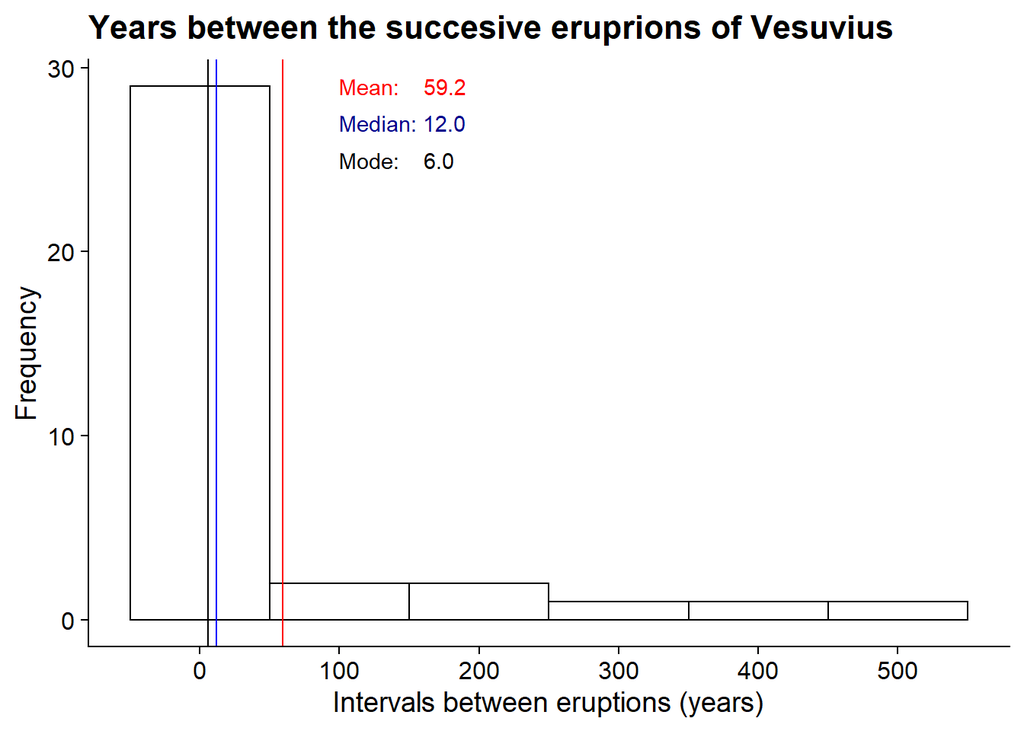

```r
limits <- pretty( vesuvius$interval,
                  n = bins,
                  high.u.bias = 10 )

############################################################################
# The bin_width is the difference between any two succesive limits.  We
# use the first two.This must be a positive interger so we subtract the
# limit[1] from Limit[2].
############################################################################

bin_width <- limits[2] - limits[1]

###########################################################################
# We plot this histogram including the mean and the median as vertical
# lines with a key.
###########################################################################

vesuvius <-
ggplot( vesuvius, aes( x = interval )) +
    geom_histogram( binwidth =  bin_width,
                     color = "black",
                     fill = "white" ) +
    geom_vline( xintercept = mean_interval,
                color = "red") +
    geom_vline( xintercept = median_interval,
                color = "blue" ) +
    geom_vline( xintercept = 6,
                color = "black" ) +
    annotate( "text",
              x = 100, y = 29,
              label = "Mean:    59.2",
              hjust = 0,
              color = "red") +
    annotate( "text",
              x = 100, y = 27,
              label = "Median: 12.0",
              hjust = 0,
              color = "darkblue" ) +
    annotate( "text",
              x = 100, y = 25,
              label = "Mode:    6.0",
              hjust = 0,
              color = "black" ) +
    scale_x_continuous( name = "Intervals between eruptions (years)",
                        breaks = limits,
                        labels = limits ) +
    ylab( "Frequency" ) +
    ggtitle( "Years between the succesive eruprions of Vesuvius" ) +
    theme_cowplot()

fp <- file.path( wd,
                 "plots",
                 "vesuvius.jpeg")

save_plot( fp, vesuvius )
vesuvius
```